# Machine Learning

Anuj Gupta

May 8, 2018

This is a R Markdown document. The purpose here is to use accelometer variables (predictors) to determine classe variables (outcome). Here we will build a model to predict the variable classe (outcome) using training dataset. This model will finally be used to determine the classe variable in testing dataset.

## Data Processing

The first step is to read the csv file for training and testing data in R. We will be removing all the columns having missing values from the dataset. Also we will be concentrating only on accelerometer variables (predictors) to build our model.

```r
pml_train <- read.csv("pml-training.csv",stringsAsFactors = T, na.strings = c("?", NA, "NA", " ", NULL, "#DIV/0!"))
pml_test <- read.csv("pml-testing.csv", stringsAsFactors = T,na.strings = c("?", NA, "NA", " ", NULL, "#DIV/0!"))
filter_col <- colSums(is.na(pml_train)) == 0 & grepl("classe|belt|arm|dumbell", names(pml_train))
#str(pml_train, list.len=ncol(pml_train))
```

## CrossValidation

We will be using the random sampling cross-validation technique to divide our training data into train and test subsets to build and validate our model respectively.

```r
inTrain <- createDataPartition(y= pml_train$classe, p= 0.7, list = FALSE)
train <- pml_train[inTrain,filter_col]
test <- pml_train[-inTrain,filter_col]
```

## Model-1

The first model we will try to build will be using Decision Trees algorithm. Here we will convert all possible correlated variables into a set of uncorrelated variables using Principal component analysis.

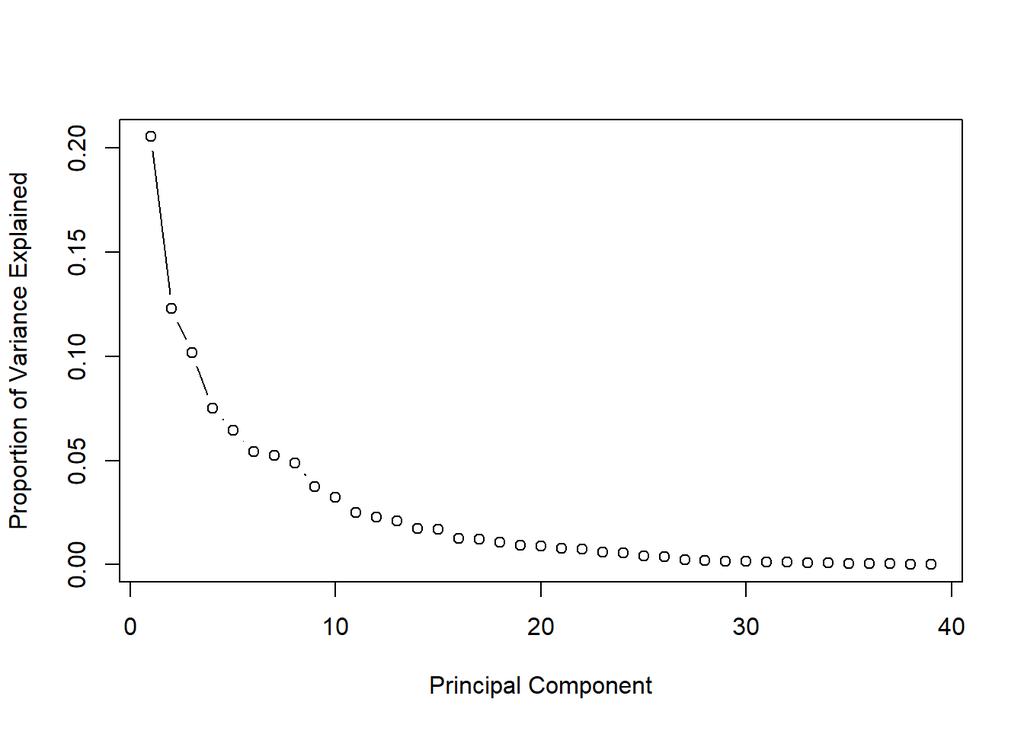

```r
set.seed(100)
prin_comp <- prcomp(train[,-40], scale. = T)
std_dev <- prin_comp$sdev
pr_var <- std_dev^2
prop_varex <- pr_var/sum(pr_var)
plot(prop_varex, xlab = "Principal Component", ylab = "Proportion of Variance Explained", type = "b")
```

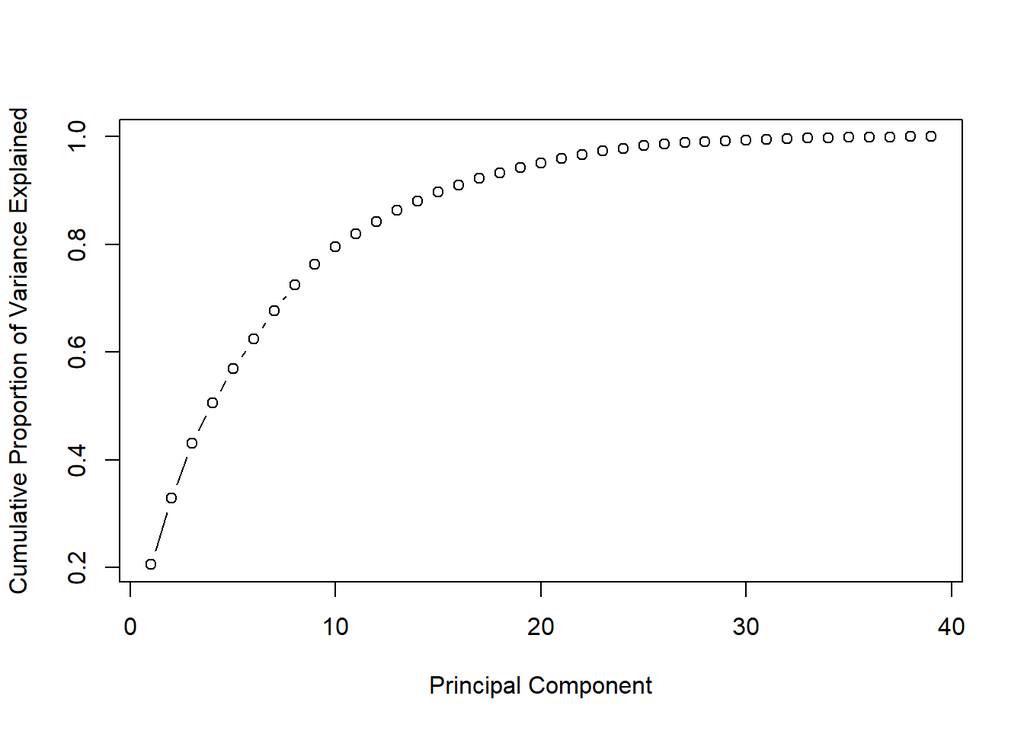

```r
plot(cumsum(prop_varex), xlab = "Principal Component", ylab = "Cumulative Proportion of Variance Explained",type = "b")
```

```r
train.data <- data.frame(classe = train$classe, prin_comp$x)
train.data <- train.data[,1:28]
test.data <- predict(prin_comp, newdata = test)
test.data <- as.data.frame(test.data)
test.data <- test.data[,1:28]
model <- rpart(classe ~ .,data = train.data, method="class")
prediction <- predict(model, test.data, type="class")
confusionMatrix(prediction, test$classe)
```

```
## Confusion Matrix and Statistics
##
##           Reference
## Prediction    A    B    C    D    E
##          A 1227  343  327  165  205
##          B   74  264  172   50  130
##          C  136  222  284  127  139
##          D  188  217  219  519  147
##          E   49   93   24  103  461
##
## Overall Statistics
##
##                Accuracy : 0.4681
##                  95% CI : (0.4553, 0.481)
##     No Information Rate : 0.2845
##     P-Value [Acc > NIR] : < 2.2e-16
##
##                   Kappa : 0.32
##  Mcnemar's Test P-Value : < 2.2e-16
##
## Statistics by Class:
##
##                      Class: A Class: B Class: C Class: D Class: E
## Sensitivity            0.7330  0.23178  0.27680  0.53838  0.42606
## Specificity            0.7530  0.91024  0.87158  0.84332  0.94399
## Pos Pred Value         0.5412  0.38261  0.31278  0.40233  0.63151
## Neg Pred Value         0.8765  0.83157  0.85091  0.90316  0.87953
## Prevalence             0.2845  0.19354  0.17434  0.16381  0.18386
## Detection Rate         0.2085  0.04486  0.04826  0.08819  0.07833
## Detection Prevalence   0.3852  0.11725  0.15429  0.21920  0.12404
## Balanced Accuracy      0.7430  0.57101  0.57419  0.69085  0.68503
```

## Model-2

The second model we will try to build will be using Random Forest algorithm with all accelerometer predictors.

```r
set.seed(200)
modfit <- randomForest(classe ~ ., data = train, ntree = 50, prox = TRUE)
pr <- predict(modfit, newdata = test)
confusionMatrix(pr, test$classe)
```

```
## Confusion Matrix and Statistics
##
##           Reference
## Prediction    A    B    C    D    E
##          A 1670    0    1    1    0
##          B    3 1133    7    1    0
##          C    1    5 1010   14    0
##          D    0    1    8  945    3
##          E    0    0    0    3 1079
##
## Overall Statistics
##
##                Accuracy : 0.9918
##                  95% CI : (0.9892, 0.994)
##     No Information Rate : 0.2845
##     P-Value [Acc > NIR] : < 2.2e-16
##
##                   Kappa : 0.9897
##  Mcnemar's Test P-Value : NA
##
## Statistics by Class:
##
##                      Class: A Class: B Class: C Class: D Class: E
## Sensitivity            0.9976   0.9947   0.9844   0.9803   0.9972
## Specificity            0.9995   0.9977   0.9959   0.9976   0.9994
## Pos Pred Value         0.9988   0.9904   0.9806   0.9875   0.9972
## Neg Pred Value         0.9991   0.9987   0.9967   0.9961   0.9994
## Prevalence             0.2845   0.1935   0.1743   0.1638   0.1839
## Detection Rate         0.2838   0.1925   0.1716   0.1606   0.1833
## Detection Prevalence   0.2841   0.1944   0.1750   0.1626   0.1839
## Balanced Accuracy      0.9986   0.9962   0.9901   0.9889   0.9983
```

## Inference

From the confusionMatrix of the two models, we can confirm that Model 2 has the highest accuracy (~99%). Hence we will be using this model to predict the classe variable from testing set.